# Step 4b - Phyloseq global and local

Create phyloseq object using global and local output.

2024-12-20

This notebook will use your data with taxonomy assigned from the latest global reference database as well as the latest project-specific local database to create a Phyloseq object for downstream analyses.

## Read in data

This code block will use the tabulated file created in Step 3 and a list of samples; it loads the cleaned global and local databases.

```r
input_path <- file.path(params$data_path, params$project_code, "merged_runs", sprintf("%s_%s", params$step_3c_analysis_date, params$user))

data_global <- read.csv(file.path(input_path, sprintf("%s_global_alluniq.clean.tag.ann.tab", params$step_3b_analysis_date)), sep="\t", header=TRUE)

data_local <- read.csv(file.path(input_path, sprintf("%s_local_alluniq.clean.tag.ann.tab", params$step_3c_analysis_date)), sep="\t", header=TRUE)

data_samples <- read.csv(params$metadata_file)
```

### Collect some insights on the shape of data

Are there the same number of sequences in your local and global files?

```r
if (length(which(data_local$id != data_global$id)) == 0){
  print("Your files have the same number of sequences.")
} else {
  print("There is a mismatch in file lengths. Please check inputs and rerun Step 3.")
}
```

```
## [1] "Your files have the same number of sequences."
```

### Rename the default column X to SampleID

```r
colnames(data_samples)[colnames(data_samples) == "X"] = params$sampleID_column
```

### Filter the data to only keep 100% matches in the local set

```r
size <- dim(data_local) #number of rows and columns
print(paste0("Number of rows in local data: ", size[1]))
```

```
## [1] "Number of rows in local data: 1033"
```

```r
print(paste0("Number of columns in local data: ", size[2]))
```

```
## [1] "Number of columns in local data: 29"
```

```r
best_id_col_local <- find_columns(data_local, starts_with("best_identity"))
best_match_col_local <- find_columns(data_local, starts_with("best_match"))

data_local <- data_local %>%
  select(-contains("obiclean_status"))

local_keep <- data_local[which(data_local[[best_id_col_local]]==params$percent_match),]

local_keep_rows <- nrow(local_keep)
print(paste0("Number of local rows kept: ", local_keep_rows))
```

```
## [1] "Number of local rows kept: 93"
```

### Filter the data to only keep 100% matches in the global set

Global only keeps perfect matches if they are not already present in the local set of matches.

```r
size <- dim(data_global) #number of rows and columns
print(paste0("Number of rows in global data: ", size[1]))
```

```
## [1] "Number of rows in global data: 1033"
```

```r
print(paste0("Number of columns in global data: ", size[2]))
```

```
## [1] "Number of columns in global data: 29"
```

```r
best_id_col <- find_columns(data_global, starts_with("best_identity"))
best_match_col <- find_columns(data_global, starts_with("best_match"))

data_global <- data_global %>%
  select(-contains("obiclean_status"))

global_keep <- data_global[intersect(which(data_global[[best_id_col]] == params$percent_match), which(data_local[[best_id_col_local]]!= params$percent_match)),]

global_keep$scientific_name <- make.unique(as.character(global_keep$scientific_name))

print(paste0("Number of global rows kept: ", nrow(global_keep)))
```

```
## [1] "Number of global rows kept: 110"
```

### Combine the local and global datasets

Combine local and additional global libraries into a database called “keep” for exploratory analyses.

```r
global_keepKEEP <- global_keep
names(global_keepKEEP) <- names(local_keep)
keep <- rbind(local_keep, global_keepKEEP)
```

### Explore the distribution of sequences

Find out distribution of the sequences you toss both locally and globally (i.e., do some match multiple species perfectly, or anything new in GenBank?).

```r
local_global_toss <- data_local[which(data_local$id %in% keep$id==F),] #tells you how many taxa didn't have 100% matches

print(paste0("The number of sequences not matching at 100%: ", dim(local_global_toss)[1]))
```

```
## [1] "The number of sequences not matching at 100%: 830"
```

```r
local_global_toss <- local_global_toss[order(local_global_toss$count,decreasing=T),]
head(local_global_toss)
```

|  | id | definition | best_identity.YNPP6_completeDB_20240430 | best_match.YNPP6_completeDB_20240430 | count | family | family_name | genus | genus_name | match_count.YNPP6_completeDB_20240430 | sample.YNP218_S1 | sample.YNP297_S13 | sample.YNP314_S25 | sample.YNP663_S19 | sample.YNP672_S81 | sample.YNP732_S46 | rank | scientific_name | species | species_list.YNPP6_completeDB_20240430 | species_name | taxid | sequence |
| --- | --- | --- | --- | --- | --- | --- | --- | --- | --- | --- | --- | --- | --- | --- | --- | --- | --- | --- | --- | --- | --- | --- | --- |
| 3 | M00763:36:000000000-K636N:1:1101:14991:1763_CONS | NA | 0.9615385 | YNPBP410-21_Geum_mac | 1378 | 3745 | Rosaceae | NA | NA | 2 | 1154 | 196 | 0 | 0 | 1 | 27 | subfamily | Rosoideae | NA | ['Geum macrophyllum', 'Fragaria virginiana'] | NA | 171638 | atcccgttttatgaaaagaaataagagtttcagaacgcgagaataaataaag |
| 7 | M00763:36:000000000-K636N:1:1101:15379:1944_CONS | NA | 0.9756098 | Polygonaceae_MIXED034 | 1155 | 3615 | Polygonaceae | NA | NA | 1 | 247 | 880 | 0 | 28 | 0 | 0 | family | Polygonaceae | NA | [] | NA | 3615 | ctcctgctttccaaactttgcaaaagggagaagaaataaag |
| 32 | M00763:36:000000000-K636N:1:1101:17413:8709_CONS | NA | 0.8750000 | Polygonaceae_MIXED001 | 923 | 3615 | Polygonaceae | NA | NA | 1 | 69 | 670 | 0 | 114 | 0 | 70 | family | Polygonaceae | NA | [] | NA | 3615 | ctcctgctttccaaaagggagaagaaataaag |
| 30 | M00763:36:000000000-K636N:1:1101:4095:8242_CONS | NA | 0.9756098 | Polygonaceae_MIXED034 | 683 | 3615 | Polygonaceae | NA | NA | 1 | 236 | 417 | 0 | 30 | 0 | 0 | family | Polygonaceae | NA | [] | NA | 3615 | ctcctgctttccaaacttttcaaaagggagaagaaataaag |
| 22 | M00763:36:000000000-K636N:1:1101:4172:5498_CONS | NA | 0.9756098 | Polygonaceae_MIXED034 | 680 | 3615 | Polygonaceae | NA | NA | 1 | 230 | 396 | 0 | 53 | 0 | 1 | family | Polygonaceae | NA | [] | NA | 3615 | ctcctgctttccaaactttccaaaagggagaaaaaataaag |
| 272 | M00763:36:000000000-K636N:1:1117:15666:3950_CONS | NA | 0.9642857 | YNPBP371-21_Polygonu | 346 | 3615 | Polygonaceae | 46786 | Polygonum | 1 | 1 | 0 | 345 | 0 | 0 | 0 | species | Polygonum douglasii | 701380 | ['Polygonum douglasii'] | Polygonum douglasii | 701380 | ctccttctttccaaaagcaagaaaaaag |

```r
# may be a couple of taxa we should look at that have 1-2 matches at ~98% match with high read count
```

### Look at a histogram of %match < 1 for the tossed samples

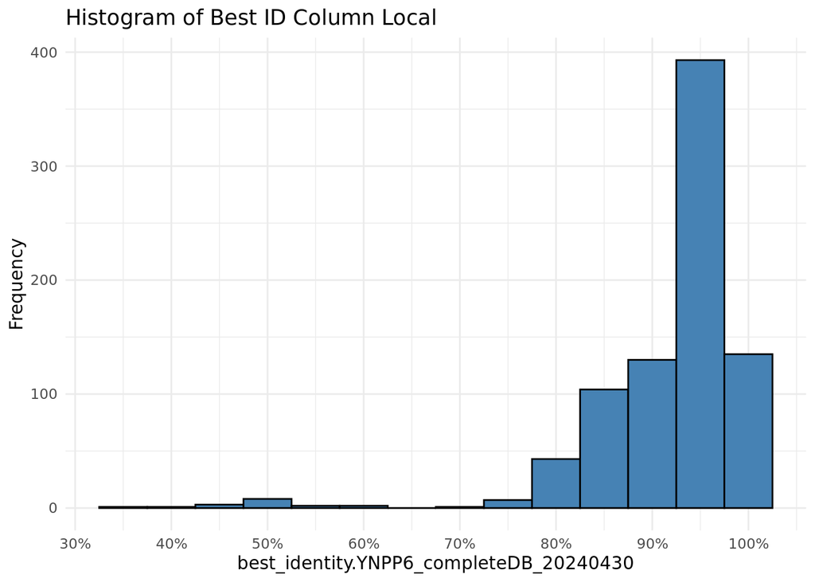

```r
ggplot(local_global_toss, aes_string(x = best_id_col_local)) +
  geom_histogram(binwidth=0.05, fill = "steelblue", color = "black") +
  labs(title = "Histogram of Best ID Column Local",
       x = best_id_col_local,
       y = "Frequency") +
  scale_x_continuous(
  breaks = seq(0, 1, by = 0.1),
  labels = scales::percent_format(scale = 100)
) +
  theme_minimal()
```

### Count up 100% matches in each family with the local library

```r
local_keep %>% count(family_name, sort = TRUE)
```

| family_name | n |
| --- | --- |
| Poaceae | 22 |
| Asteraceae | 11 |
| Cyperaceae | 9 |
| Brassicaceae | 5 |
| Fabaceae | 4 |
| Plantaginaceae | 4 |
| Polemoniaceae | 4 |
| Polygonaceae | 4 |
| Ranunculaceae | 4 |
| Rosaceae | 4 |

[output cut: 17 more lines]

### Count up 100% matches in each genera with the local library

```r
local_keep %>% count(genus_name, sort = TRUE)
```

| genus_name | n |
| --- | --- |
| NA | 29 |
| Bromus | 5 |
| Carex | 5 |
| Arabis | 2 |
| Astragalus | 2 |
| Hesperostipa | 2 |
| Heuchera | 2 |
| Phlox | 2 |
| Ranunculus | 2 |
| Alyssum | 1 |

[output cut: 41 more lines]

### Count up 100% matches in each family with the global library

```r
global_keep_families <- global_keep %>% count(family_name, sort = TRUE)
global_keep_families
```

| family_name | n |
| --- | --- |
| Rosaceae | 11 |
| NA | 10 |
| Asteraceae | 8 |
| Caryophyllaceae | 8 |
| Poaceae | 7 |
| Brassicaceae | 5 |
| Polemoniaceae | 5 |
| Cyperaceae | 4 |
| Fabaceae | 4 |
| Ericaceae | 3 |

[output cut: 32 more lines]

```r
write.csv(global_keep_families, file.path(input_path, "global_keep_familes.csv"))
```

### Count up 100% matches in each genera with the global library

```r
global_keep_genera <- global_keep %>% count(genus_name, sort = TRUE)
global_keep_genera
```

| genus_name | n |
| --- | --- |
| NA | 36 |
| Bromus | 5 |
| Carex | 4 |
| Phlox | 4 |
| Stellaria | 3 |
| Allium | 2 |
| Geranium | 2 |
| Geum | 2 |
| Orthocarpus | 2 |
| Potentilla | 2 |

[output cut: 46 more lines]

```r
write.csv(global_keep_genera, file.path(input_path, "global_keep_genera.csv"))
```

## Inspect the 90-99% matches

```r
local_nineties <- filter(data_local, between(data_local[[best_id_col_local]], 0.9, 1)) %>%
  arrange(desc(best_id_col_local))
local_nineties %>% count(family_name, sort = TRUE) #families with lots of reads matching at 90-99.99%
```

| family_name | n |
| --- | --- |
| Poaceae | 165 |
| Asteraceae | 127 |
| Rosaceae | 114 |
| Polygonaceae | 107 |
| Cyperaceae | 49 |
| Saxifragaceae | 30 |
| Caryophyllaceae | 29 |
| Onagraceae | 24 |
| Brassicaceae | 19 |
| Polemoniaceae | 17 |

[output cut: 22 more lines]

```r
global_nineties <- filter(data_global, between(data_global[[best_id_col]], 0.9, 1)) %>%
  arrange(desc(best_id_col))
global_nineties %>% count(family_name, sort = TRUE) #families with lots of reads matching at 90-99.99%
```

| family_name | n |
| --- | --- |
| NA | 273 |
| Poaceae | 148 |
| Polygonaceae | 108 |
| Geraniaceae | 59 |
| Cyperaceae | 54 |
| Pinaceae | 44 |
| Rosaceae | 36 |
| Caryophyllaceae | 29 |
| Saxifragaceae | 25 |
| Onagraceae | 23 |

[output cut: 36 more lines]

Filter for records in the global that are a 100% match not already matched at 100% in the local db.

```r
global_nineties_keep <- global_nineties[intersect(which(global_nineties[[best_id_col]] == params$percent_match), which(data_local[[best_id_col_local]] != params$percent_match)),]
```

## Generate summary statistics for publication

#### Median and max for local and global counts

```r
print(paste0("The median counts for the local keep subset: ", median(local_keep$count)))
```

```
## [1] "The median counts for the local keep subset: 160"
```

```r
print(paste0("The median counts for the global keep subset: ", median(global_keep$count)))
```

```
## [1] "The median counts for the global keep subset: 27.5"
```

```r
print(paste0("The maximum counts for the local keep subset: ", max(local_keep$count)))
```

```
## [1] "The maximum counts for the local keep subset: 51445"
```

```r
print(paste0("The maximum counts for the global keep subset: ", max(global_keep$count)))
```

```
## [1] "The maximum counts for the global keep subset: 27281"
```

#### Sample read depths

This will make tables with the depths for each sample in each data subset.

```r
depth <- as.data.frame(t(colSums(data_local[,grep("sample\\.", colnames(data_local))])))
depth_local_only <- as.data.frame(t(colSums(local_keep[,grep("sample\\.", colnames(local_keep))])))
depth_global_only <- as.data.frame(t(colSums(global_keep[,grep("sample\\.", colnames(global_keep))])))
depth_local_and_global <- as.data.frame(t(colSums(keep[,grep("sample\\.", colnames(keep))])))

#combine into one result df; view the new 'sample_depth' dataframe for comparisons
sample_depths <- bind_rows(
  depth = depth,
  depth_local_only = depth_local_only,
  depth_global_only = depth_global_only,
  depth_local_and_global = depth_local_and_global,
  .id = "source"
)
```

#### Proportions discarded with each subset

```r
sample_depths <- sample_depths %>%
  pivot_longer(cols = -source, names_to = "sample", values_to = "value") %>%
  pivot_wider(names_from = source, values_from = value) %>%
  group_by(sample) %>%
  mutate(prop_kept_local = depth_local_only / depth,
         prop_kept_global = depth_global_only / depth,
         prop_kept_both = depth_local_and_global / depth,
         reads_discarded = 1 - prop_kept_both,
         !!sym(params$sampleID_column) := substring(sample, 8, 13)) %>%
  ungroup() %>%
  left_join(data_samples %>%
              select(!!sym(params$sampleID_column), !!sym(params$major_grouping)), by = setNames(params$sampleID_column, params$sampleID_column))

write.csv(sample_depths, "./sample_depths.csv")
sample_depths
```

| sample | depth | depth_local_only | depth_global_only | depth_local_and_global | prop_kept_local | prop_kept_global | prop_kept_both | reads_discarded | SampleID | Species |
| --- | --- | --- | --- | --- | --- | --- | --- | --- | --- | --- |
| sample.YNP218_S1 | 40662 | 18818 | 18858 | 37676 | 0.4627908 | 0.46377453 | 0.9265653 | 0.07343466 | YNP218 | BISON |
| sample.YNP297_S13 | 47191 | 29355 | 14227 | 43582 | 0.6220466 | 0.30147698 | 0.9235236 | 0.07647645 | YNP297 | BISON |
| sample.YNP314_S25 | 54194 | 43403 | 8582 | 51985 | 0.8008820 | 0.15835701 | 0.9592390 | 0.04076097 | YNP314 | BISON |
| sample.YNP663_S19 | 58484 | 49970 | 7209 | 57179 | 0.8544217 | 0.12326448 | 0.9776862 | 0.02231380 | YNP663 | PRONGHORN |
| sample.YNP672_S81 | 43885 | 39213 | 3234 | 42447 | 0.8935399 | 0.07369261 | 0.9672325 | 0.03276746 | YNP672 | BIGHORN SHEEP |
| sample.YNP732_S46 | 32481 | 14521 | 17019 | 31540 | 0.4470614 | 0.52396786 | 0.9710292 | 0.02897078 | YNP732 | MULE DEER |

#### Plot proportional changes at sample level if you add or don’t add the global perfect matches to the local perfect matches

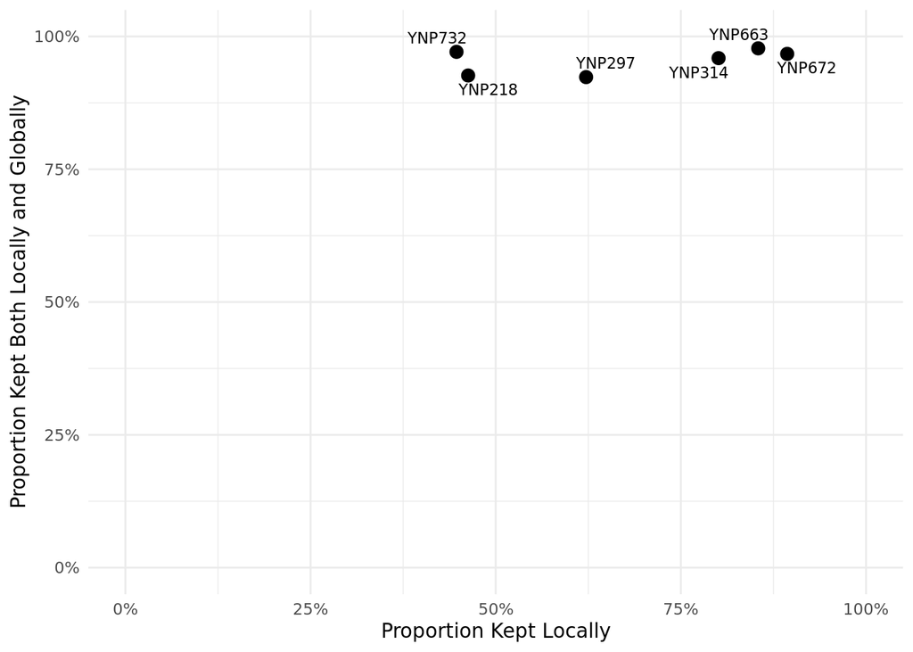

```r
ggplot(sample_depths, aes(x = prop_kept_local, y = prop_kept_both)) +
  geom_point(size=3) +
  geom_text_repel(aes(label = !!sym(params$sampleID_column)),
                  size=3)+
  labs(x = "Proportion Kept Locally",
       y = "Proportion Kept Both Locally and Globally") +
  scale_y_continuous(
  labels = percent,
  limits = c(0, 1),
) +
  scale_x_continuous(
  labels = percent,
  limits = c(0, 1),
) +
  theme_minimal()
```

#### Plot proportions from each subset by major gouping

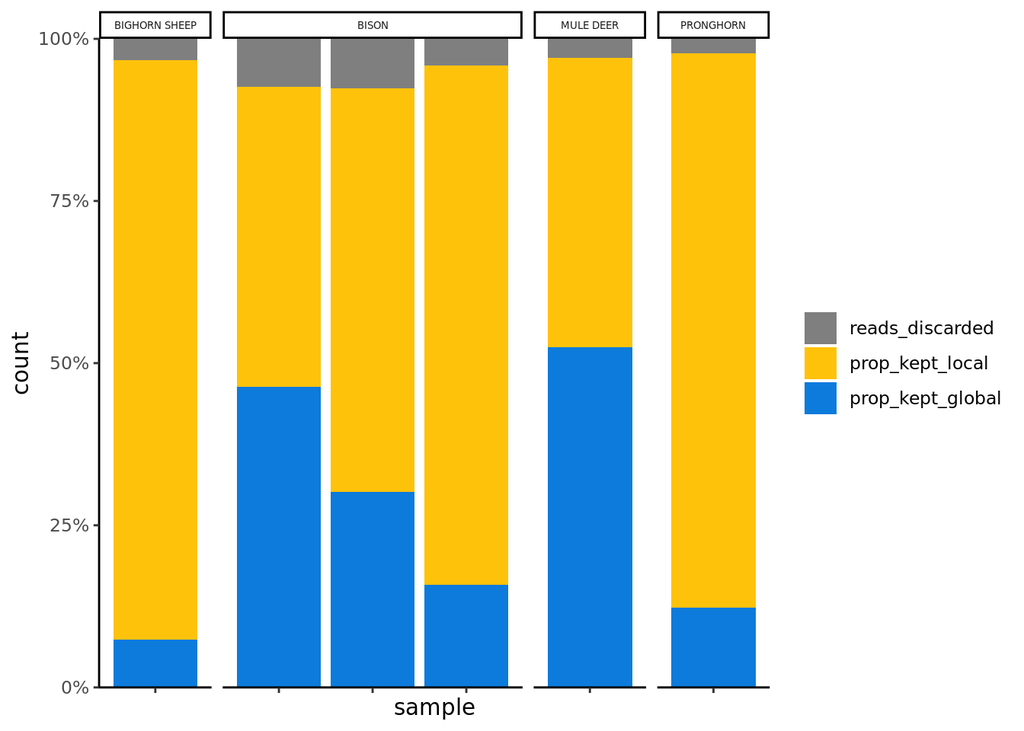

```r
sample_depths %>%
  gather(type, count, prop_kept_local:prop_kept_global:reads_discarded) %>%
  filter(type != "prop_kept_both") %>%
  ggplot(., aes(x=sample, y=count, fill=forcats::fct_rev(type))) +
  scale_fill_manual(values = c("grey50", "#FFC20A", "#0C7BDC")) +
  geom_bar(stat="identity") +
  theme_classic()+
  theme(legend.title=element_blank(),
        axis.text.x=element_blank()) +
  scale_y_continuous(
  labels = percent,
  limits = c(0, 1),
  expand = expansion(0, 0)
) +
  facet_grid(reformulate(params$major_grouping),
           scales = "free", space = "free") +
  theme(strip.text = element_text(
    size = 5))
```

#### Print some important metrics overall

```r
#should be 90% to 80%
print(paste0("Overall proportion of reads retained with local and global combined: ", sprintf(sum(sample_depths$depth_local_and_global)/sum(sample_depths$depth),fmt='%#.3f')))
```

```
## [1] "Overall proportion of reads retained with local and global combined: 0.955"
```

```r
#should be 67% to 61%
print(paste0("Proportion of reads retained with just local: ", sprintf(sum(sample_depths$depth_local_only)/sum(sample_depths$depth),fmt='%#.3f')))
```

```
## [1] "Proportion of reads retained with just local: 0.705"
```

```r
#should be 23% to 27%
print(paste0("Additional proportion of reads retained with just global: ", sprintf(sum(sample_depths$depth_global_only)/sum(sample_depths$depth),fmt='%#.3f')))
```

```
## [1] "Additional proportion of reads retained with just global: 0.250"
```

#### 100% matches in local that were new to global

```r
global_match <- data_global[which(data_global[[best_id_col]] == 1),]

global_missing <- subset(local_keep, !(id %in% global_match$id)) %>%
  arrange(desc(count))

global_missing_trim <- select(global_missing, starts_with("sample."))

global_missing_RRA <- as.matrix(global_missing_trim) %o% as.matrix(1/sample_depths$depth_local_and_global)

global_missing_RRA_max <- round(apply(global_missing_RRA, 1, max, na.rm=TRUE), digits=6)
global_missing_RRA_mean <- round(apply(global_missing_RRA, 1, mean, na.rm=TRUE), digits=6)

global_missing_RRA_info <- cbind(global_missing %>% select(sequence, taxid, species_name, count, genus_name, family_name, starts_with(c("species_list", "best_", "match_"))), global_missing_RRA_max, global_missing_RRA_mean)
global_missing_RRA_info
```

| sequence | taxid | species_name | count | genus_name | family_name | species_list.YNPP6_completeDB_20240430 | best_identity.YNPP6_completeDB_20240430 | best_match.YNPP6_completeDB_20240430 | match_count.YNPP6_completeDB_20240430 | global_missing_RRA_max | global_missing_RRA_mean |
| --- | --- | --- | --- | --- | --- | --- | --- | --- | --- | --- | --- |
| atcctcttttaccaaactaaacccaaatacaggggtttaatttaaaaagcgagaataaaaaag | 306558 | Sedum lanceolatum | 610 | Sedum | Crassulaceae | ['Sedum lanceolatum'] | 1 | YNPBP150-21_Sedum_la | 1 | 0.015250 | 0.002397 |
| atcctatcttttcaaaatatgggttcagaaagcgaaaaaggg | 160360 | Collinsia parviflora | 180 | Collinsia | Plantaginaceae | ['Collinsia parviflora'] | 1 | YNPBP436-21_Collinsi | 1 | 0.002758 | 0.000707 |
| atcttcttttttagaaaaagaaatatataaaatatttcttatttcagataagaaagaatattatttcttatctaatattaaa | 240693 | Carex vallicola | 160 | Carex | Cyperaceae | ['Carex vallicola'] | 1 | YNPBP565-22_Carex_va | 1 | 0.004819 | 0.000629 |
| atcacgttttccgaaaacaaccaaaggttcagaaagcgaaaatcaaaaag | 196514 | Symphyotrichum foliaceum | 46 | Symphyotrichum | Asteraceae | ['Symphyotrichum foliaceum'] | 1 | YNPBP076-21_Symphyot | 1 | 0.000888 | 0.000181 |
| atccctttttttttcgaaaacaaacaaagattcggaaagtaaaaataagaatcaaaaggaag | 1570906 | Phlox multiflora | 32 | Phlox | Polemoniaceae | ['Phlox multiflora'] | 1 | YNPBP340-21_Phlox_mu | 1 | 0.000888 | 0.000126 |
| atccttttttcgaaaacaaacaaagattcggaaagtaaaaataagaataaaaaggagg | 91557 | Leptosiphon septentrionalis | 2 | Leptosiphon | Polemoniaceae | ['Leptosiphon septentrionalis'] | 1 | YNPBP343-21_Leptosip | 1 | 0.000063 | 0.000008 |

## Sample-wise Relative Read Abundance

Sample-wise distribution of reads retained/discarded based on local and/or global criteria.

```r
#Calculate range of RRA change when global matches are added in
additional_RRA_with_global <- round(sample_depths$prop_kept_both - sample_depths$prop_kept_local, digits=3)
RRA_range_global <-  range(additional_RRA_with_global)
print(glue("Range of RRA with global: ", RRA_range_global[1], "-", RRA_range_global[2]))
```

```
## Range of RRA with global: 0.074-0.524
```

```r
print(glue("Median RRA with global across samples: ", median(additional_RRA_with_global)))
```

```
## Median RRA with global across samples: 0.2295
```

```r
print(glue("Mean RRA with global across samples: ", mean(additional_RRA_with_global)))
```

```
## Mean RRA with global across samples: 0.274
```

```r
#If >75% of samples gain less than 1% of reads back by including the global, we're in good shape; however, a subset of samples (<5%) could gain back a rather high percentage (>61%), suggesting that we should facilitate
print(glue("Quantiles of RRA with global: "))
```

```
## Quantiles of RRA with global:
```

```r
quantile(additional_RRA_with_global,c(0.75, 0.95,1))
```

```
##     75%     95%    100%
## 0.42325 0.50900 0.52400
```

## Disproportionality

Figure out whether any of the global matches contribute disproportionately. Report global-matching-taxa that contribute more than 5% of a sample’s reads; within those samples, what are the mean, median, and max values?

```r
#This block makes an empty matrix with as many rows as we need for each sequence identified in the global_keep subset
global_keep_plants <- matrix(nrow=nrow(global_keep), ncol=4)
rownames(global_keep_plants) <- as.character(global_keep$scientific_name)
colnames(global_keep_plants) <- c("length", "mean", "median", "maximum")
```

This block will loop through each taxa and calculate metrics for each taxa that has at least 1 sample with RRA > RRA_threshold.

```r
for(i in 1:nrow(global_keep_plants)){
  sample_cols = global_keep[i,grep("sample\\.", colnames(global_keep))]
  global_keep_plants[i,1] <- length(which((sample_cols/depth) > params$RRA_threshold))

  if(global_keep_plants[i, "length"] >= 1){

      global_keep_plants[i, "mean"] <- mean(as.numeric(sample_cols[which((sample_cols/depth) > params$RRA_threshold)])  /  as.numeric(depth[which((sample_cols/depth) > params$RRA_threshold)]))

      global_keep_plants[i, "median"] <- median(as.numeric(global_keep[i, grep("sample\\.", colnames(global_keep))][which((sample_cols/depth) > params$RRA_threshold)])  /  as.numeric(depth[which((sample_cols/depth) > params$RRA_threshold)]))

      global_keep_plants[i, "maximum"] <- max(as.numeric(global_keep[i, grep("sample\\.", colnames(global_keep))][which((sample_cols/depth) > params$RRA_threshold)])  /  as.numeric(depth[which((sample_cols/depth) > params$RRA_threshold)]))
  }
}

global_keep_plants <- as.data.frame(global_keep_plants) %>% drop_na()
```

Print out some overall metrics about disproportionality in the dataset.

```r
print(glue("Number of disproportionate taxa: ", nrow(global_keep_plants)))
```

```
## Number of disproportionate taxa: 4
```

```r
range_of_dis_lengths <- range(global_keep_plants$length)
print(glue("Range of sequence counts: ", range_of_dis_lengths[1], "-", range_of_dis_lengths[2]))
```

```
## Range of sequence counts: 1-3
```

```r
range_of_dis_means <- round(range(global_keep_plants$mean), 3)
print(glue("Range of means: ", range_of_dis_means[1], "-", range_of_dis_means[2]))
```

```
## Range of means: 0.073-0.46
```

```r
range_of_dis_maxs <- round(range(global_keep_plants$maximum), 3)
print(glue("Range of maximums: ", range_of_dis_maxs[1], "-", range_of_dis_maxs[2]))
```

```
## Range of maximums: 0.073-0.46
```

## Summarize local and non-trace global

Make a new dataframe containing the local matches and the non-trace global matches and calculate summary stats. Non-trace global matches = higher abundance global matches (e.g. >5%).

```r
global_nontrace <- global_keep[which(global_keep$scientific_name%in%rownames(global_keep_plants)),]
colnames(global_nontrace) <- names(local_keep)
global_nontrace
```

|  | id | definition | best_identity.YNPP6_completeDB_20240430 | best_match.YNPP6_completeDB_20240430 | count | family | family_name | genus | genus_name | match_count.YNPP6_completeDB_20240430 | sample.YNP218_S1 | sample.YNP297_S13 | sample.YNP314_S25 | sample.YNP663_S19 | sample.YNP672_S81 | sample.YNP732_S46 | rank | scientific_name | species | species_list.YNPP6_completeDB_20240430 | species_name | taxid | sequence |
| --- | --- | --- | --- | --- | --- | --- | --- | --- | --- | --- | --- | --- | --- | --- | --- | --- | --- | --- | --- | --- | --- | --- | --- |
| 1 | M00763:36:000000000-K636N:1:1101:18003:1562_CONS | NA | 1 | AJ297326 | 7900 | 3745 | Rosaceae | 3761 | Geum | 1 | 6358 | 1039 | 1 | 431 | 0 | 71 | genus | Geum | NA | [] | NA | 3761 | atcccgttttatgaaaagaaataagggtttcagaacgcgagaataaataaag |
| 6 | M00763:36:000000000-K636N:1:1101:8944:1919_CONS | NA | 1 | AB219634 | 27281 | 4027 | Geraniaceae | 4028 | Geranium | 1 | 10614 | 11263 | 5402 | 2 | 0 | 0 | genus | Geranium | NA | [] | NA | 4028 | atccttttttacgaaaataaagagggtctcagaaagcgagaatagaaaaaaaag |
| 29 | M00763:36:000000000-K636N:1:1101:18575:8206_CONS | NA | 1 | AB219593 | 5319 | NA | NA | NA | NA | 1 | 206 | 96 | 670 | 4271 | 29 | 47 | clade | campanulids | NA | [] | NA | 91882 | atcacgttttccgaaaacaaacaaaggttcagaaagcgaaaagaaaaaaaa |
| 153 | M00763:36:000000000-K636N:1:1105:6916:18457_CONS | NA | 1 | AB045064 | 15786 | 3318 | Pinaceae | NA | NA | 1 | 13 | 16 | 20 | 800 | 1 | 14936 | family | Pinaceae | NA | [] | NA | 3318 | atccggttcatggagacaatggtttcttctcctaggataggaaggg |

```r
local_nontrace_global <- rbind(local_keep, global_nontrace)
lng_dims <- dim(local_nontrace_global)
print(glue("There are ", lng_dims[1], " sequence records in the local + global_nontrace subset and ", lng_dims[2], " columns."))
```

```
## There are 97 sequence records in the local + global_nontrace subset and 23 columns.
```

Calculate sample-wise retention of RRA.

```r
local_nontrace_global_depth <- colSums(local_nontrace_global[,grep("sample\\.", colnames(local_nontrace_global))])

proportion_depth_kept_lng <- local_nontrace_global_depth/as.matrix(depth)
as.data.frame(proportion_depth_kept_lng)
```

| sample.YNP218_S1 | sample.YNP297_S13 | sample.YNP314_S25 | sample.YNP663_S19 | sample.YNP672_S81 | sample.YNP732_S46 |
| --- | --- | --- | --- | --- | --- |
| 0.8855688 | 0.8851052 | 0.9133114 | 0.9485329 | 0.8942235 | 0.9105323 |

Print metrics about sample-wise retention of RRA.

```r
print(glue("Quantiles of RRA with local + global nontrace: "))
```

```
## Quantiles of RRA with local + global nontrace:
```

```r
quantile(proportion_depth_kept_lng)
```

```
##        0%       25%       50%       75%      100%
## 0.8851052 0.8877325 0.9023779 0.9126167 0.9485329
```

```r
#proportion of overall reads kept
print(glue("\n
Total local + global notrace depth: ", sum(local_nontrace_global_depth)))
```

```
##
## Total local + global notrace depth: 251566
```

```r
print(glue("Total local + global notrace depth retained: ", round(sum(local_nontrace_global_depth)/sum(as.matrix(depth)), 3)))
```

```
## Total local + global notrace depth retained: 0.909
```

## Summarize sample sizes

```r
local_nontrace_global_stats <- as.data.frame(cbind(tapply(local_nontrace_global_depth, paste(data_samples[[params$minor_grouping]], data_samples[[params$major_grouping]]), mean), tapply(local_nontrace_global_depth, paste(data_samples[[params$minor_grouping]], data_samples[[params$major_grouping]]), sd), tapply(local_nontrace_global_depth, paste(data_samples[[params$minor_grouping]], data_samples[[params$major_grouping]]), function(x) length(x))))

colnames(local_nontrace_global_stats) <- c("mean","sd", "length")

local_nontrace_global_stats
```

|  | mean | sd | length |
| --- | --- | --- | --- |
| FALL BISON | 49496 | NA | 1 |
| SPRING BIGHORN SHEEP | 39243 | NA | 1 |
| SPRING BISON | 38889 | 4072.935 | 2 |
| SPRING MULE DEER | 29575 | NA | 1 |
| SPRING PRONGHORN | 55474 | NA | 1 |

## Save outputs and generate Phyloseq object

```r
#Make the OTU table.
OTU_table <- keep %>%
  select(starts_with("sample.")) %>%
  rename_with(~ str_remove_all(., "sample.|_S\\d+"), starts_with("sample.")) %>%
  as_tibble(rownames = "row_id") %>%
  mutate(row_id = paste0("P", row_id)) %>%
  column_to_rownames("row_id")

#Make the Taxa table.
Taxa_table <- keep %>%
  select(-starts_with("sample.")) %>%
  relocate(id, definition, all_of(best_id_col_local), all_of(best_match_col_local), count, .after = last_col()) %>%
  as_tibble(rownames = "row_id") %>%
  mutate(row_id = paste0("P", row_id)) %>%
  column_to_rownames("row_id")

#Set the index of the samples data to sample names; Phyloseq needs this to match up teh different shapes of OTU, TAX, and Samples tables
rownames(data_samples)<- data_samples[[params$sampleID_column]]
```

```r
OTU = otu_table(as.matrix(OTU_table), taxa_are_rows = TRUE)
TAX = tax_table(as.matrix(Taxa_table))
samples = sample_data(data_samples)

filename <- glue({params$project_code}, "_diet_local_global_", {params$todaydate}, ".rds")
phyloseq_object <- phyloseq(OTU, TAX, samples)
phyloseq_object
```

```
## phyloseq-class experiment-level object
## otu_table()   OTU Table:         [ 203 taxa and 6 samples ]
## sample_data() Sample Data:       [ 6 samples by 16 sample variables ]
## tax_table()   Taxonomy Table:    [ 203 taxa by 17 taxonomic ranks ]
```

```r
saveRDS(phyloseq_object, filename)

# WE HAVE A NEW PHYLOSEQ OBJECT!!!
```